# Weekly Butter Prices from 2012 to 2017

March 2020

# Introduction

Keeping track of the food price on industrial scale is an important measure to regulate the food market. [The Mandatory Price Reporting Act of 2010](https://www.congress.gov/111/plaws/publ239/PLAW-111publ239.pdf) requires the USDA to release dairy product sales information on or before Wednesday at 3:00 pm EST (unless affected by a Federal Holiday). This weekly reported price information offers insight into time trend of several dairy products in the past few years.

The data is collected from [Kaggle](https://www.kaggle.com/sohier/weekly-dairy-product-prices) and belongs to [USDA](https://mpr.datamart.ams.usda.gov/menu.do?path=\Products\Dairy). The data contain prices (dollars per pound) of five different kinds of dairy products from March 2012 to December 2017. This project zooms in on the price of butter alone.

# Data Cleaning and Exploration

The data cleaning addresses three issues with the raw data. The first issue is duplicate entries in the dataset that need to be removed. The second issue is multiple entries of prices taken on the same day. A plausible solution is to aggregate these prices and take the average. The third issue is that some adjacent time points don’t differ by 7 days. A simple approach is to only retain those time points whose date differs from the very first day in the dataset (2012/03/03) by multiples of 7.

Data processing retains 286 weekly data points from 2012/03/03 to 2017/08/19. The points are plotted below

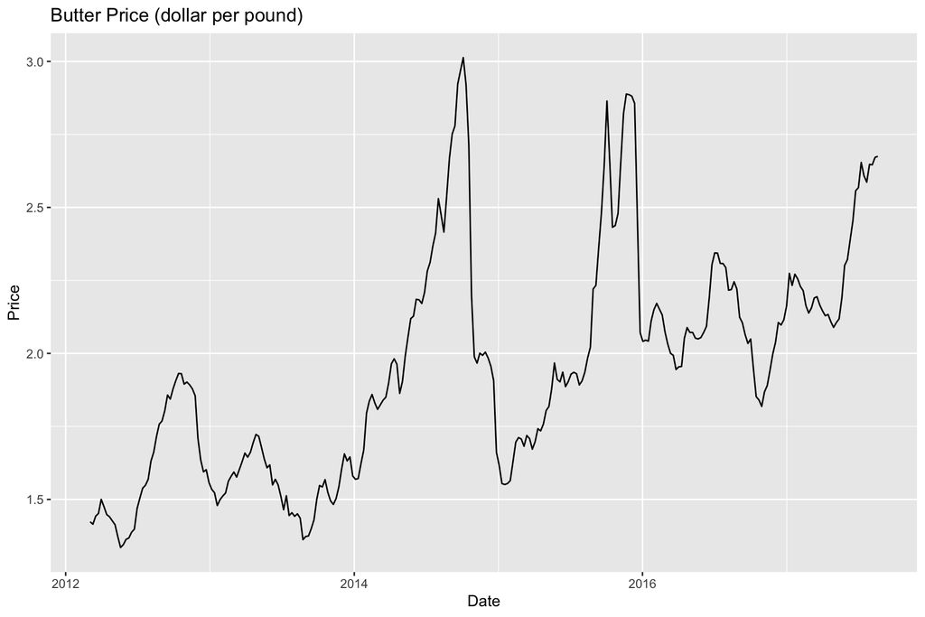

The line plot shows strong trend in the data (not simply white noise). There are large short term fluctuations together with a seemingly increasing trend on a global scale.

# Methodology

Based on the plot of the raw prices above, I decide to first decompose the price trend into a long term trend, a short term trend and noise using loess smoothing with two different spans. For the short term trend, I plan to carry out spectral analysis and identify potential significant frequencies. For the long term trend, I plan to use ARMA models and their derivatives(SARMA, regression with ARMA errors) to explain the time series trend parametrically.

# Results

## Spectral Analysis for Short Term Trend

First the signal is separated into long term trend, short term trend and noise. The long term trend is acquired by loess smoothing at a span of 0.5. The noise is acquired by subtracting the original signal by the signal after loess smoothing at a span of 0.1. The choices of the spans follow the practice in [class](https://ionides.github.io/531w20/08/notes08.pdf). The short term signal is calculated by subtracting the original signal by both the long term trend and the noise.

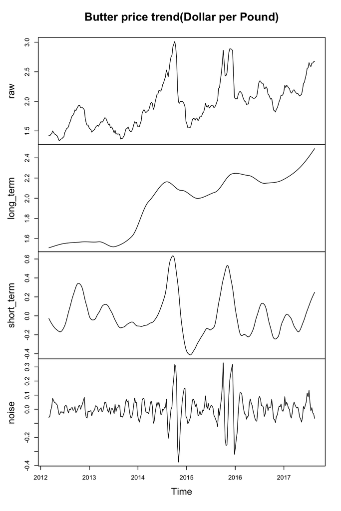

The spectrum of the short term signal is plotted below with the period set to be a year (52 weeks). A red threshold line at $5\times 10^{-3}$ is added for reference given that the smallest unit of price is one cent.

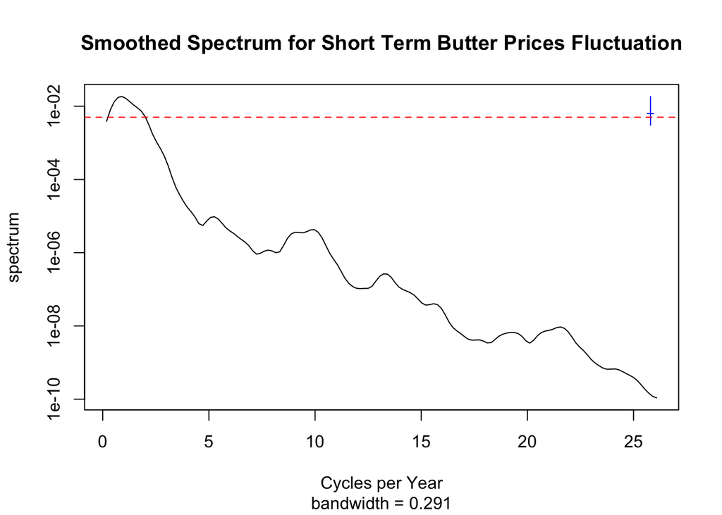

On this spectrum, the peak of the spectrum has a density of 0.018 at 0.906 cycles per year. It indicates that there is a notable periodicity of one cycle per year.

## ARMA Models for Long Term Trend

The long term trend is already plotted in the previous section. Based on the shape of the line, a linear model is worth trying. In the plot below, the X axis is the week number with the first observation in the data on 2012/03/03 set as one.

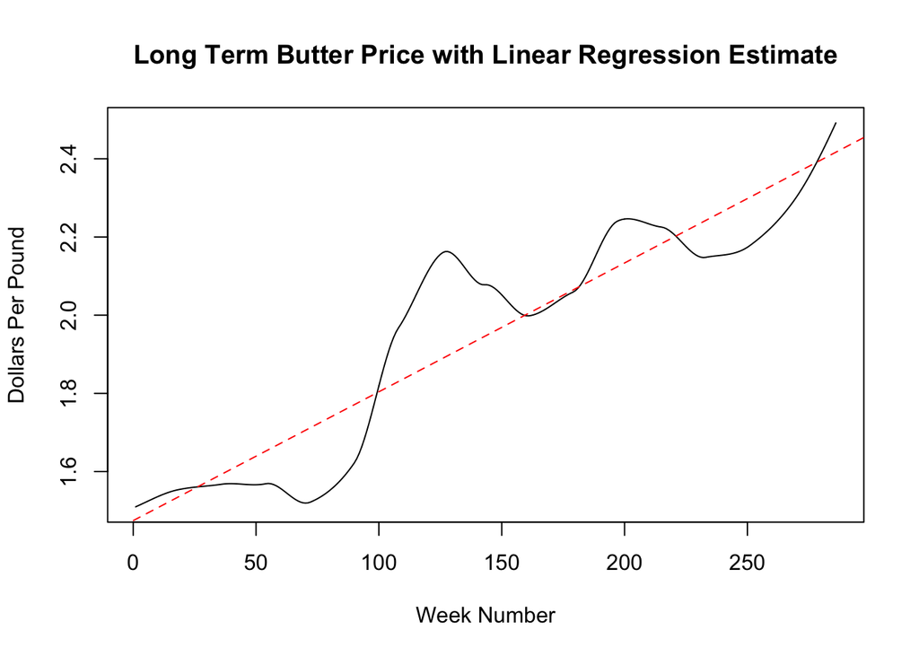

The linear model generates a visually good fit. The summary statistic of the model confirms our guess with high R-square value.

```
##
## Call:
## lm(formula = long_term ~ date)
##
## Residuals:
##       Min        1Q    Median        3Q       Max
## -0.191091 -0.089437 -0.005452  0.064953  0.270405
##
## Coefficients:
##             Estimate Std. Error t value Pr(>|t|)
## (Intercept) 1.474602   0.013411  109.96   <2e-16 ***
## date        0.003295   0.000081   40.67   <2e-16 ***
## ---
## Signif. codes:  0 '***' 0.001 '**' 0.01 '*' 0.05 '.' 0.1 ' ' 1
##
## Residual standard error: 0.1131 on 284 degrees of freedom
## Multiple R-squared:  0.8535, Adjusted R-squared:  0.853
## F-statistic:  1654 on 1 and 284 DF,  p-value: < 2.2e-16
```

Although the R square is very high, the scatterplot and the autocorrelation plot of the residuals tell us that the residuals violate the constant variance and independence assumption.

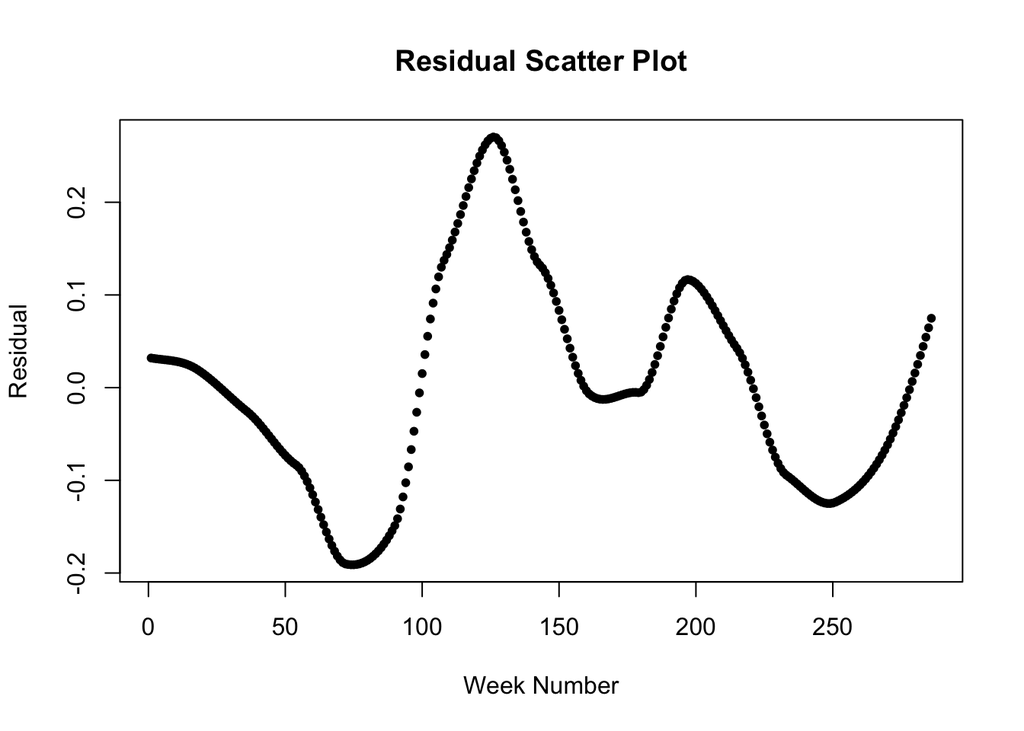

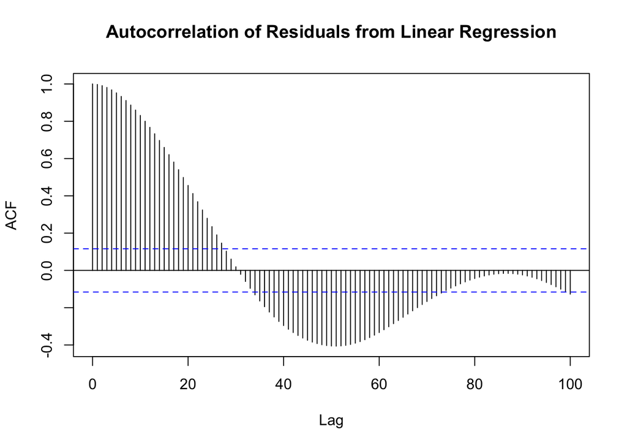

Given that the autocorrelation at small lags are very large, ARMA models on differences of adjacent residuals could be helpful for stablizing the autocorrelation. I carry out a grid search for ideal AR components and MA components of a candidate ARIMA model, as taught in [class](https://ionides.github.io/531w20/05/notes05.pdf).

|  | MA0 | MA1 | MA2 | MA3 | MA4 | MA5 |
| --- | --- | --- | --- | --- | --- | --- |
| AR0 | -2024.192 | -2409.407 | -2783.383 | -3095.843 | -3328.633 | -3487.999 |
| AR1 | -3230.896 | -3590.915 | -3779.325 | -3852.451 | -3886.078 | -3900.954 |
| AR2 | -3756.354 | -3930.074 | -3928.415 | -3926.579 | -3924.950 | -3923.114 |
| AR3 | -3839.539 | -3928.438 | -3927.592 | -3924.467 | -3922.782 | -3920.900 |
| AR4 | -3862.532 | -3926.645 | -3924.497 | -3925.869 | -3921.937 | -3921.997 |

The table tells us that ARIMA(2,1,1) model is the strongest candidate. The model formula is laid out below (written in lag operators). $\{Y_{n}\}$ are the residuals from the linear model and $\{\epsilon_{n}\}$ are assumed to be white noise.

$$(1-\phi_{1}B-\phi_{2}B^{2})[(1-B)Y_{n}]=(1+\psi_{1}B)\epsilon_{n}$$

```
##
## Call:
## arima(x = slrresiduals, order = c(2, 1, 1))
##
## Coefficients:
##          ar1      ar2     ma1
##       1.8276  -0.8416  0.9408
## s.e.  0.0314   0.0315  0.0241
##
## sigma^2 estimated as 5.615e-08:  log likelihood = 1969.04,  aic = -3930.07
```

Fill in the paramters for the model

$$(1-1.828B+0.842B^{2})[(1-B)Y_{n}]=(1+0.941B)\epsilon_{n}$$
in which $\{\epsilon_{n}\}$ are a series of normal white noise with a variance of $5.62\times 10^{-8}$.